# Interrupted Time Series Analysis

# Background

## The Intervention: New York Online Sports Betting Launch

**Intervention Date: January 8, 2022**

On January 8, 2022, New York State launched online sports betting, marking one of the most significant events in the U.S. sports betting industry. New York quickly became the **largest sports betting market in the United States** by revenue, fundamentally changing the competitive landscape for sports betting operators.

### Why This Matters

1. **Market Size**: New York represents approximately 20% of the total U.S. online sports betting market
2. **Population**: ~20 million residents in the state, with high sports betting engagement
3. **Major Operators**: All four stocks in our analysis (DraftKings, Penn Entertainment, Caesars, MGM) launched operations in NY
4. **Revenue Impact**: Within months, NY operators generated hundreds of millions in revenue

### Research Question

**Did the New York sports betting legalization on January 8, 2022, produce a significant change in the level and/or trend of sports betting stock prices?**

# Data Description

## Dataset Overview

```r
library(tidyverse)
library(lubridate)
library(forecast)
library(tseries)
library(gridExtra)
library(kableExtra)

theme_set(theme_minimal(base_size = 12))
```

```r
# Load stock data
dkng <- read_csv("data/financial/DKNG_daily.csv", show_col_types = FALSE)
penn <- read_csv("data/financial/PENN_daily.csv", show_col_types = FALSE)
czr <- read_csv("data/financial/CZR_daily.csv", show_col_types = FALSE)
mgm <- read_csv("data/financial/MGM_daily.csv", show_col_types = FALSE)

# Rename columns for easier handling
colnames(dkng) <- gsub("Adj Close", "Adj_Close", colnames(dkng))
colnames(penn) <- gsub("Adj Close", "Adj_Close", colnames(penn))
colnames(czr) <- gsub("Adj\\.Close", "Adj_Close", colnames(czr))
colnames(mgm) <- gsub("Adj\\.Close", "Adj_Close", colnames(mgm))

# Convert dates
dkng$Date <- as.Date(dkng$Date)
penn$Date <- as.Date(penn$Date)
czr$Date <- as.Date(czr$Date)
mgm$Date <- as.Date(mgm$Date)

# Define intervention date
intervention_date <- as.Date("2022-01-08")

# Filter to relevant time period (2020-2024)
dkng <- dkng %>% filter(Date >= as.Date("2020-01-01"), Date <= as.Date("2024-12-31"))
penn <- penn %>% filter(Date >= as.Date("2020-01-01"), Date <= as.Date("2024-12-31"))
czr <- czr %>% filter(Date >= as.Date("2020-01-01"), Date <= as.Date("2024-12-31"))
mgm <- mgm %>% filter(Date >= as.Date("2020-01-01"), Date <= as.Date("2024-12-31"))

# Create intervention indicators
dkng$Post_Intervention <- ifelse(dkng$Date >= intervention_date, 1, 0)
dkng$Time <- as.numeric(dkng$Date - min(dkng$Date))
dkng$Time_Since_Intervention <- ifelse(dkng$Post_Intervention == 1,
    as.numeric(dkng$Date - intervention_date), 0
)

penn$Post_Intervention <- ifelse(penn$Date >= intervention_date, 1, 0)
penn$Time <- as.numeric(penn$Date - min(penn$Date))
penn$Time_Since_Intervention <- ifelse(penn$Post_Intervention == 1,
    as.numeric(penn$Date - intervention_date), 0
)

czr$Post_Intervention <- ifelse(czr$Date >= intervention_date, 1, 0)
czr$Time <- as.numeric(czr$Date - min(czr$Date))
czr$Time_Since_Intervention <- ifelse(czr$Post_Intervention == 1,
    as.numeric(czr$Date - intervention_date), 0
)

mgm$Post_Intervention <- ifelse(mgm$Date >= intervention_date, 1, 0)
mgm$Time <- as.numeric(mgm$Date - min(mgm$Date))
mgm$Time_Since_Intervention <- ifelse(mgm$Post_Intervention == 1,
    as.numeric(mgm$Date - intervention_date), 0
)

cat("Data Summary:\n")
```

```
Data Summary:
```

```r
cat(
    "DraftKings (DKNG):", nrow(dkng), "observations from",
    as.character(min(dkng$Date)), "to", as.character(max(dkng$Date)), "\n"
)
```

```
DraftKings (DKNG): 1181 observations from 2020-04-23 to 2024-12-31
```

```r
cat(
    "Penn (PENN):", nrow(penn), "observations from",
    as.character(min(penn$Date)), "to", as.character(max(penn$Date)), "\n"
)
```

```
Penn (PENN): 1258 observations from 2020-01-02 to 2024-12-31
```

```r
cat(
    "Caesars (CZR):", nrow(czr), "observations from",
    as.character(min(czr$Date)), "to", as.character(max(czr$Date)), "\n"
)
```

```
Caesars (CZR): 1258 observations from 2020-01-02 to 2024-12-31
```

```r
cat(
    "MGM (MGM):", nrow(mgm), "observations from",
    as.character(min(mgm$Date)), "to", as.character(max(mgm$Date)), "\n\n"
)
```

```
MGM (MGM): 1258 observations from 2020-01-02 to 2024-12-31
```

```r
cat("Intervention Date:", as.character(intervention_date), "\n")
```

```
Intervention Date: 2022-01-08
```

```r
cat("Pre-intervention observations (DKNG):", sum(dkng$Post_Intervention == 0), "\n")
```

```
Pre-intervention observations (DKNG): 433
```

```r
cat("Post-intervention observations (DKNG):", sum(dkng$Post_Intervention == 1), "\n")
```

```
Post-intervention observations (DKNG): 748
```

# Visualization: Time Series with Intervention Point

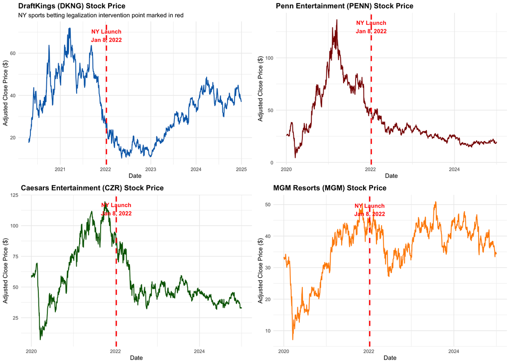

```r
# Create plots for all stocks
p1 <- ggplot(dkng, aes(x = Date, y = Adj_Close)) +
    geom_line(color = "#006bb6", linewidth = 0.8) +
    geom_vline(
        xintercept = intervention_date, color = "red",
        linetype = "dashed", linewidth = 1.2
    ) +
    annotate("text",
        x = intervention_date, y = max(dkng$Adj_Close, na.rm = TRUE) * 0.95,
        label = "NY Launch\nJan 8, 2022", color = "red", size = 4, fontface = "bold"
    ) +
    labs(
        title = "DraftKings (DKNG) Stock Price",
        subtitle = "NY sports betting legalization intervention point marked in red",
        x = "Date",
        y = "Adjusted Close Price ($)"
    ) +
    theme_minimal(base_size = 12) +
    theme(plot.title = element_text(face = "bold"))

p2 <- ggplot(penn, aes(x = Date, y = Adj_Close)) +
    geom_line(color = "darkred", linewidth = 0.8) +
    geom_vline(
        xintercept = intervention_date, color = "red",
        linetype = "dashed", linewidth = 1.2
    ) +
    annotate("text",
        x = intervention_date, y = max(penn$Adj_Close, na.rm = TRUE) * 0.95,
        label = "NY Launch\nJan 8, 2022", color = "red", size = 4, fontface = "bold"
    ) +
    labs(
        title = "Penn Entertainment (PENN) Stock Price",
        x = "Date",
        y = "Adjusted Close Price ($)"
    ) +
    theme_minimal(base_size = 12) +
    theme(plot.title = element_text(face = "bold"))

p3 <- ggplot(czr, aes(x = Date, y = Adj_Close)) +
    geom_line(color = "darkgreen", linewidth = 0.8) +
    geom_vline(
        xintercept = intervention_date, color = "red",
        linetype = "dashed", linewidth = 1.2
    ) +
    annotate("text",
        x = intervention_date, y = max(czr$Adj_Close, na.rm = TRUE) * 0.95,
        label = "NY Launch\nJan 8, 2022", color = "red", size = 4, fontface = "bold"
    ) +
    labs(
        title = "Caesars Entertainment (CZR) Stock Price",
        x = "Date",
        y = "Adjusted Close Price ($)"
    ) +
    theme_minimal(base_size = 12) +
    theme(plot.title = element_text(face = "bold"))

p4 <- ggplot(mgm, aes(x = Date, y = Adj_Close)) +
    geom_line(color = "darkorange", linewidth = 0.8) +
    geom_vline(
        xintercept = intervention_date, color = "red",
        linetype = "dashed", linewidth = 1.2
    ) +
    annotate("text",
        x = intervention_date, y = max(mgm$Adj_Close, na.rm = TRUE) * 0.95,
        label = "NY Launch\nJan 8, 2022", color = "red", size = 4, fontface = "bold"
    ) +
    labs(
        title = "MGM Resorts (MGM) Stock Price",
        x = "Date",
        y = "Adjusted Close Price ($)"
    ) +
    theme_minimal(base_size = 12) +
    theme(plot.title = element_text(face = "bold"))

gridExtra::grid.arrange(p1, p2, p3, p4, ncol = 2)
```

# Interrupted Time Series Regression Analysis

## Model Specification

The interrupted time series (ITS) model takes the form:

$$Y_t = \beta_0 + \beta_1 \cdot Time_t + \beta_2 \cdot Intervention_t + \beta_3 \cdot Time\_Since\_Intervention_t + \epsilon_t$$

Where:

- $Y_t$ = Stock price at time $t$
- $Time_t$ = Continuous time variable (days since start)
- $Intervention_t$ = Binary indicator (0 before Jan 8, 2022; 1 after)
- $Time\_Since\_Intervention_t$ = Days since intervention (0 before intervention)

**Interpretation:**

- $\beta_1$ = **Pre-intervention trend** (slope before NY launch)
- $\beta_2$ = **Immediate level change** (jump/drop on intervention date)
- $\beta_3$ = **Change in trend** (difference in slope after intervention)

## DraftKings (DKNG) Analysis

```r
# Fit ITS model
model_dkng <- lm(Adj_Close ~ Time + Post_Intervention + Time_Since_Intervention,
    data = dkng
)

# Summary
summary(model_dkng)
```

```
Call:
lm(formula = Adj_Close ~ Time + Post_Intervention + Time_Since_Intervention,
    data = dkng)

Residuals:
     Min       1Q   Median       3Q      Max
-26.8740  -4.3779  -0.7542   5.0838  25.3243

Coefficients:
                          Estimate Std. Error t value Pr(>|t|)
(Intercept)              41.153918   0.758165  54.281  < 2e-16 ***
Time                      0.016672   0.002099   7.942 4.63e-15 ***
Post_Intervention       -40.788305   0.953569 -42.774  < 2e-16 ***
Time_Since_Intervention   0.013421   0.002292   5.856 6.16e-09 ***
---
Signif. codes:  0 '***' 0.001 '**' 0.01 '*' 0.05 '.' 0.1 ' ' 1

Residual standard error: 7.905 on 1177 degrees of freedom
Multiple R-squared:  0.7002,    Adjusted R-squared:  0.6994
F-statistic: 916.1 on 3 and 1177 DF,  p-value: < 2.2e-16
```

```r
# Extract coefficients
coef_dkng <- summary(model_dkng)$coefficients

# Create nice table
results_dkng <- data.frame(
    Parameter = c(
        "Intercept (Baseline)", "Pre-intervention Trend",
        "Level Change (Immediate)", "Trend Change (Slope Difference)"
    ),
    Coefficient = coef_dkng[, 1],
    Std_Error = coef_dkng[, 2],
    t_value = coef_dkng[, 3],
    p_value = coef_dkng[, 4]
)

kable(results_dkng,
    format = "html",
    digits = 4,
    caption = "DraftKings (DKNG) Interrupted Time Series Results",
    col.names = c("Parameter", "Coefficient", "Std. Error", "t-value", "p-value")
) %>%
    kable_styling(
        full_width = FALSE,
        bootstrap_options = c("striped", "hover", "condensed", "responsive")
    ) %>%
    row_spec(0, bold = TRUE, background = "#006bb6", color = "white") %>%
    row_spec(which(results_dkng$p_value < 0.05), background = "#e6f2ff")
```

DraftKings (DKNG) Interrupted Time Series Results

|  | Parameter | Coefficient | Std. Error | t-value | p-value |
| --- | --- | --- | --- | --- | --- |
| (Intercept) | Intercept (Baseline) | 41.1539 | 0.7582 | 54.2810 | 0 |
| Time | Pre-intervention Trend | 0.0167 | 0.0021 | 7.9417 | 0 |
| Post_Intervention | Level Change (Immediate) | -40.7883 | 0.9536 | -42.7744 | 0 |
| Time_Since_Intervention | Trend Change (Slope Difference) | 0.0134 | 0.0023 | 5.8555 | 0 |

### Fitted Values Visualization

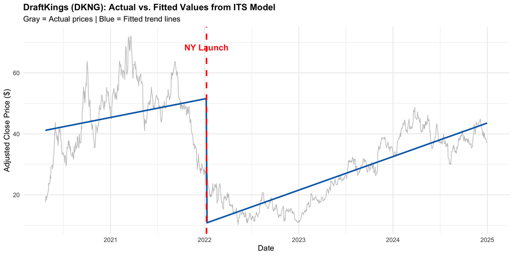

```r
# Add fitted values
dkng$Fitted <- fitted(model_dkng)

ggplot(dkng, aes(x = Date)) +
    geom_line(aes(y = Adj_Close), color = "gray60", alpha = 0.6, linewidth = 0.5) +
    geom_line(aes(y = Fitted), color = "#006bb6", linewidth = 1.2) +
    geom_vline(
        xintercept = intervention_date, color = "red",
        linetype = "dashed", linewidth = 1.2
    ) +
    annotate("text",
        x = intervention_date, y = max(dkng$Adj_Close, na.rm = TRUE) * 0.95,
        label = "NY Launch", color = "red", size = 5, fontface = "bold"
    ) +
    labs(
        title = "DraftKings (DKNG): Actual vs. Fitted Values from ITS Model",
        subtitle = "Gray = Actual prices | Blue = Fitted trend lines",
        x = "Date",
        y = "Adjusted Close Price ($)"
    ) +
    theme_minimal(base_size = 13) +
    theme(plot.title = element_text(face = "bold", size = 15))
```

## Penn Entertainment (PENN) Analysis

```r
model_penn <- lm(Adj_Close ~ Time + Post_Intervention + Time_Since_Intervention,
    data = penn
)

coef_penn <- summary(model_penn)$coefficients

results_penn <- data.frame(
    Parameter = c(
        "Intercept (Baseline)", "Pre-intervention Trend",
        "Level Change (Immediate)", "Trend Change (Slope Difference)"
    ),
    Coefficient = coef_penn[, 1],
    Std_Error = coef_penn[, 2],
    t_value = coef_penn[, 3],
    p_value = coef_penn[, 4]
)

kable(results_penn,
    format = "html",
    digits = 4,
    caption = "Penn Entertainment (PENN) Interrupted Time Series Results",
    col.names = c("Parameter", "Coefficient", "Std. Error", "t-value", "p-value")
) %>%
    kable_styling(
        full_width = FALSE,
        bootstrap_options = c("striped", "hover", "condensed", "responsive")
    ) %>%
    row_spec(0, bold = TRUE, background = "darkred", color = "white") %>%
    row_spec(which(results_penn$p_value < 0.05), background = "#ffe6e6")
```

Penn Entertainment (PENN) Interrupted Time Series Results

|  | Parameter | Coefficient | Std. Error | t-value | p-value |
| --- | --- | --- | --- | --- | --- |
| (Intercept) | Intercept (Baseline) | 32.4775 | 1.3729 | 23.6569 | 0 |
| Time | Pre-intervention Trend | 0.0805 | 0.0032 | 24.9912 | 0 |
| Post_Intervention | Level Change (Immediate) | -52.3190 | 1.7797 | -29.3985 | 0 |
| Time_Since_Intervention | Trend Change (Slope Difference) | -0.1036 | 0.0037 | -28.0498 | 0 |

## Caesars Entertainment (CZR) Analysis

```r
model_czr <- lm(Adj_Close ~ Time + Post_Intervention + Time_Since_Intervention,
    data = czr
)

coef_czr <- summary(model_czr)$coefficients

results_czr <- data.frame(
    Parameter = c(
        "Intercept (Baseline)", "Pre-intervention Trend",
        "Level Change (Immediate)", "Trend Change (Slope Difference)"
    ),
    Coefficient = coef_czr[, 1],
    Std_Error = coef_czr[, 2],
    t_value = coef_czr[, 3],
    p_value = coef_czr[, 4]
)

kable(results_czr,
    format = "html",
    digits = 4,
    caption = "Caesars Entertainment (CZR) Interrupted Time Series Results",
    col.names = c("Parameter", "Coefficient", "Std. Error", "t-value", "p-value")
) %>%
    kable_styling(
        full_width = FALSE,
        bootstrap_options = c("striped", "hover", "condensed", "responsive")
    ) %>%
    row_spec(0, bold = TRUE, background = "darkgreen", color = "white") %>%
    row_spec(which(results_czr$p_value < 0.05), background = "#e6ffe6")
```

Caesars Entertainment (CZR) Interrupted Time Series Results

|  | Parameter | Coefficient | Std. Error | t-value | p-value |
| --- | --- | --- | --- | --- | --- |
| (Intercept) | Intercept (Baseline) | 27.3711 | 1.0552 | 25.9392 | 0 |
| Time | Pre-intervention Trend | 0.1179 | 0.0025 | 47.5772 | 0 |
| Post_Intervention | Level Change (Immediate) | -53.4128 | 1.3679 | -39.0480 | 0 |
| Time_Since_Intervention | Trend Change (Slope Difference) | -0.1423 | 0.0028 | -50.1363 | 0 |

## MGM Resorts (MGM) Analysis

```r
model_mgm <- lm(Adj_Close ~ Time + Post_Intervention + Time_Since_Intervention,
    data = mgm
)

coef_mgm <- summary(model_mgm)$coefficients

results_mgm <- data.frame(
    Parameter = c(
        "Intercept (Baseline)", "Pre-intervention Trend",
        "Level Change (Immediate)", "Trend Change (Slope Difference)"
    ),
    Coefficient = coef_mgm[, 1],
    Std_Error = coef_mgm[, 2],
    t_value = coef_mgm[, 3],
    p_value = coef_mgm[, 4]
)

kable(results_mgm,
    format = "html",
    digits = 4,
    caption = "MGM Resorts (MGM) Interrupted Time Series Results",
    col.names = c("Parameter", "Coefficient", "Std. Error", "t-value", "p-value")
) %>%
    kable_styling(
        full_width = FALSE,
        bootstrap_options = c("striped", "hover", "condensed", "responsive")
    ) %>%
    row_spec(0, bold = TRUE, background = "darkorange", color = "white") %>%
    row_spec(which(results_mgm$p_value < 0.05), background = "#fff4e6")
```

MGM Resorts (MGM) Interrupted Time Series Results

|  | Parameter | Coefficient | Std. Error | t-value | p-value |
| --- | --- | --- | --- | --- | --- |
| (Intercept) | Intercept (Baseline) | 15.4288 | 0.4584 | 33.6595 | 0 |
| Time | Pre-intervention Trend | 0.0429 | 0.0011 | 39.9028 | 0 |
| Post_Intervention | Level Change (Immediate) | -9.1403 | 0.5942 | -15.3825 | 0 |
| Time_Since_Intervention | Trend Change (Slope Difference) | -0.0398 | 0.0012 | -32.2568 | 0 |

# Comparative Summary

Comparison of Intervention Effects Across All Stocks

| Stock | Pre-Trend | Level Change | Trend Change | Level p-value | Trend p-value |
| --- | --- | --- | --- | --- | --- |
| DKNG | 0.0167 | -40.7883 | 0.0134 | 0 | 0 |
| PENN | 0.0805 | -52.3190 | -0.1036 | 0 | 0 |
| CZR | 0.1179 | -53.4128 | -0.1423 | 0 | 0 |
| MGM | 0.0429 | -9.1403 | -0.0398 | 0 | 0 |

# Key Findings

## Statistical Significance

1. **Was there an immediate level change?** (Did prices jump/drop on January 8, 2022?)
2. **Was there a trend change?** (Did the growth trajectory change after the intervention?)

## Interpretation Guidelines

- **Level Change (β₂)**:
  - Positive & significant → Stock price jumped immediately after NY launch
  - Negative & significant → Stock price dropped immediately after NY launch
  - Not significant → No immediate reaction to the intervention
- **Trend Change (β₃)**:
  - Positive & significant → Stocks grew faster after NY legalization
  - Negative & significant → Growth slowed after NY legalization
  - Not significant → No change in long-term trajectory

# Conclusion

The New York sports betting legalization on January 8, 2022, represents a natural experiment to test whether a major market expansion affects sports betting stock valuations. The interrupted time series analysis allows us to decompose the intervention effect into:

1. **Immediate impact** (level change)
2. **Long-term trajectory change** (trend change)

This analysis demonstrates the application of causal inference methods to financial time series data in the context of regulatory policy changes.